# Best Practise in R

02/12/2021

## Best Practise in R

R is an open source ecosystem with vast array of different packages from many different authors, evolving of over many years and across multiple different disciples. There are no agreed conventions, even within base R.

GABurns

This makes it difficult for a R user to know what convention to adopt.

*Aim:* To *stimulate* discussion on best practise, *signpost* to resources & *suggest* some approaches to take.

## Key messages

The key take home messages from the *Jumping Rivers* course were:

- Write code for humans to understand, not computers
- Best Practise is subjective and specific to individual use-cases
- Adopt conventions, document them and be *consistent* within a Team
- Adopting best practice may not save you time short term but will save time in long term

## Naming Conventions

Code will run without a standard naming convention but it will make it difficult for others to read and interpret the code. It can lead to bugs, difficulty to communicate what the code does and inefficiencies.  
Some things we name in R: - Files - Functions - Arguments - Variables - Classes

## Style Guidelines

- Put space after a *comma* and not before
- Put space before and after an *equals* sign
- Use assignment operator (<-) for created functions and variables
- Maximum 80 characters per line
- Indent curly brackets (RStudio: *Crtl + Shift + A*)

## Modularise Code

## Lessons Learnt 1

The precedence of a function will depend on the order you load packages. You can call a function from a specific package using the syntax > package_name::function_name

## Lessons Learnt 2

Don’t *hard-code* variables, create a variable at start of script.

```r
library(palmerpenguins)
library(ggplot2)

gentooData <- penguins[penguins$species == "Gentoo", ]

ggplot(data = gentooData,
       aes(x = flipper_length_mm,
           y = body_mass_g)) +
  geom_point(aes(color = "Red"),
    size = 3 ) +
      labs(
        title = "Relationship between flipper length and body mass for Gentoo Penguins",
        caption = "Data Source: Palmers Penguins",
        x = "Flipper length (mm)",
        y = "Body mass (g)",
      ) +
      theme_minimal(
      )
```

## Lessons Learnt 2

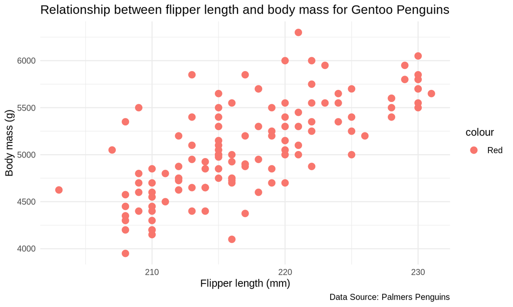

## Lessons Learnt 2

Copy and pasting code is a common practice but but can lead to errors that aren’t always picked up on.

```r
library(palmerpenguins)
library(ggplot2)

chinstrapData <- penguins[penguins$species == "Chinstrap", ]

ggplot(data = chinstrapData,
       aes(x = flipper_length_mm,
           y = body_mass_g)) +
  geom_point(aes(color = "Red"),
    size = 3 ) +
      labs(
        title = "Relationship between flipper length and body mass for Gentoo Penguins",
        caption = "Data Source: Palmers Penguins",
        x = "Flipper length (mm)",
        y = "Body mass (g)"
      ) +
      theme_minimal()
```

[output not shown]